# Estadísticas de Facebook

Benjamín Urrutia

30-10-2020

# Resúmen

En este informe se analizará la base de datos `facebook metrics` para ver cuál tipo de publicación, foto, estado, link o video, nos conviene realizar para generar un mayor impacto en esta red social. Estudiaremos las variables más significativas de esta base de datos para realizar el análisis. Luego concluiremos, dependiendo nuestro objetivo, qué publicar para poder llegar a un mayor número de personas y hacer crecer nuestra página.

# Introducción

Hoy en día las redes sociales son cada vez más comunes entre las personas, llegando al punto en el que es muy difícil conocer a alguien que no utilice Twitter, Instagram o **Facebook**. Esta última mencionada es una de las más conocidas. Se estima que hay alrededor de unos **2.400 millones de usuarios activos**(1). A nivel mundial, sabemos que millones de personas publican distintos tipos de post y cada uno con distintos objetivos, como por ejemplo, vender un producto, informar sobre algún tema, etc.

Muchos usuarios buscan crecer en la red social. Para lograr esto, **es de suma importancia saber cómo se comporta tu post**. Es por esto que Facebook implementó estadísticas de cada publicación que uno realiza. Independiente de cual sea el objetivo, uno puede tener información sobre el alcance, número de likes, interacciones, entre otras cosas. No obstante, muchos usuarios no saben cómo utilizar esta herramienta para sacarle un mejor provecho a sus páginas.

Es por esto que en este informe se busca **examinar qué impacto tiene, en Facebook, cada tipo de post**. Vamos a analizar el alcance, el número de interacciones, de likes, de comentarios, entre otros. Para ello, estudiaremos por separado cada tipo de publicación: videos, fotos, estados y links.

En este trabajo vamos a **analizar detalladamente las variables más influyentes** de la base de datos `Facebook metrics Data Set`. Cada variable va a tener una breve explicación de lo que representa. Luego vamos a ver, a través de gráficos y medidas de resúmen, cómo se comporta cada tipo de post para concluir si nos conviene compartir un video, una foto, un estado o un link, para tener un mayor impacto en esta red social.

# Metodología

En este informe analizaremos 10 variables de nuestra base de datos. De las cuales hay 2 variables categóricas y 8 númericas. Para realizar el estudio, utilizaremos gráfico de barra y boxplot. Este último está explicado dentro del informe, en la sección `alcance total`. Además utilizaremos estadísticos de resúmen, como la media, desviación estándar, mediana, mínimo y máximo, los cuales los organizaremos en tablas.

# Resultados

Estudiemos cómo se comportan las distinas variables de nuestra base de datos.

## Distintos tipos de post

Para partir nuestro análisis veamos qué tipos de post existen y qué tantas publicaciones tienen cada uno de estos.

En nuestro caso tenemos 4 tipos de publicaciones. En primer lugar, tenemos el post tipo `Link` que consiste en un enlace para acceder a otra página web. En segundo lugar, el tipo `Photo` es el que contiene una imágen. En tercer lugar, `Status` se refiere a las publicaciones que son solamente texto. Finalmente, los `Videos` son aquellas que contienen material audiovisual.

Veamos gráficamente qué sucede en nuestros datos.

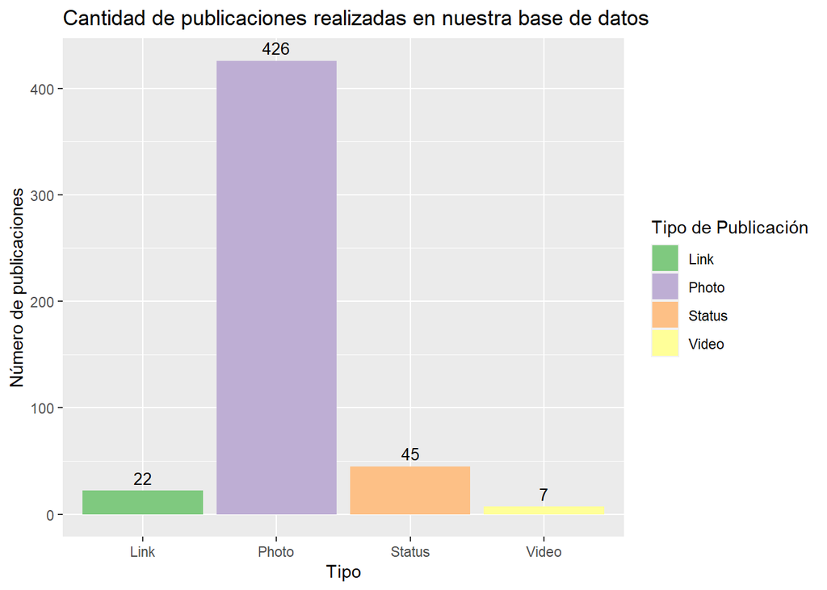

Como podemos ver en el gráfico, el número de publicaciones de fotos (`Photo`) es mucho más alto en comparación al resto de los tipos post.

Podemos notar la diferencia también en la siguiente tabla

| Tipo de Post | Porcentaje del Total |
| --- | --- |
| Link | 4.4% |
| Foto | 85.2% |
| Video | 1.4% |
| Estado | 9% |

Notamos que las fotos corresponden a un 85.2% de las publicaciones totales, mientras que el resto de publicaciones solo abarcan un 14.8%. Es por esto que analizar, por ejemplo, el total de likes de cada publicación no tiene mucho sentido ya que, al haber más fotos, el total de likes va a ser mayor que el resto. No obstante, esto no significa que una foto tenga más likes que un video. Por esta razón, nuestro análisis se va a enfocar en cada tipo de post y cómo se comporta.

## Categoría de la publicación

Esta variable cuenta con tres tipos de categorias: **Action (1)**, **Product (2)** y **Inspiration (3)**. La categoria *action* se refiere a **ofertas especiales y concursos**, *Product* hace referencia a **publicidad directa con contenido de marca explícito** y, por último, *Inspiration* está relacionado con un post **sin contenido de marca explícito**.

Veamos gráficamente cómo se comportan

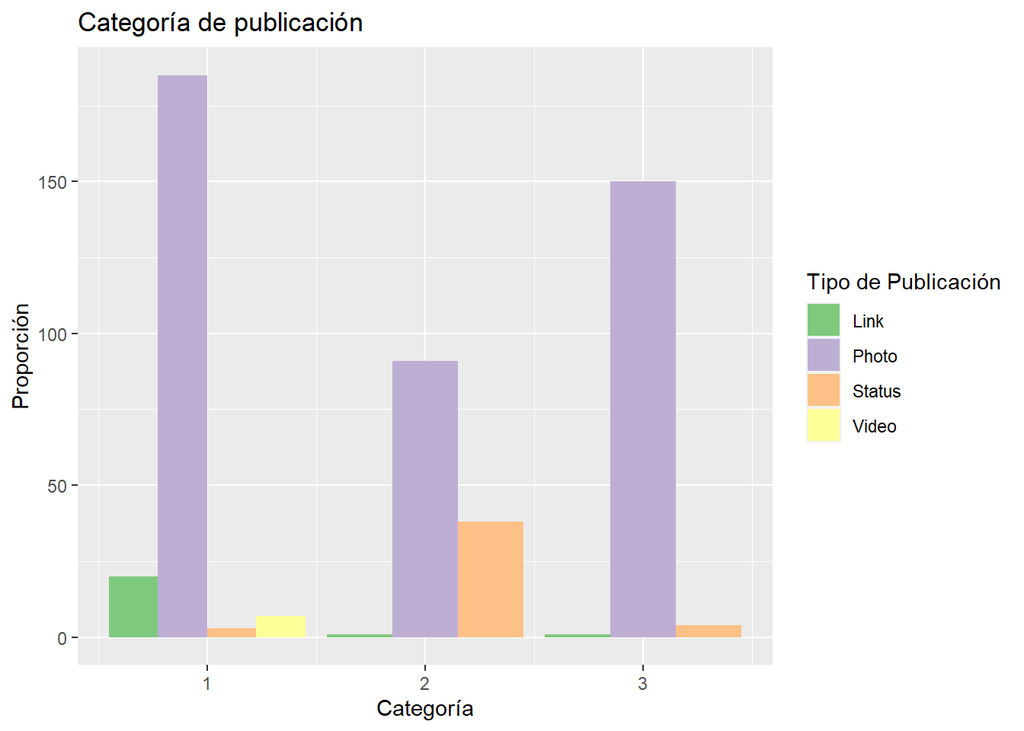

Veamos numéricamente cómo se comporta cada tipo publicación

| Tipo de Post | Categoria 1 | Categoria 2 | Categoria 3 |
| --- | --- | --- | --- |
| Link | 20 | 1 | 1 |
| Foto | 185 | 91 | 150 |
| Video | 7 | 0 | 0 |
| Estado | 3 | 38 | 4 |

Como mencionamos antes, generalmente los links y videos son para concursos y ofertas especiales, mientras que los estados se relacionan en su mayoría con publicidad directa. Sobre las fotos, podemos notar que hay una gran cantidad dentro de la categoria Action, seguido de Inspiration y, por último, Product.

Teniendo en cuenta como se suelen utlizan los tipos de post, veamos los impactos que estos tienen dentro de Facebook.

## Alcance total

La variable `Alcance total` se refiere a la cantidad de usuarios únicos que vieron tu post, es decir, si un mismo usuario ve tu publicación dos veces, solo se contabiliza una.

Analicemos mediante un Boxplot cómo se comportan

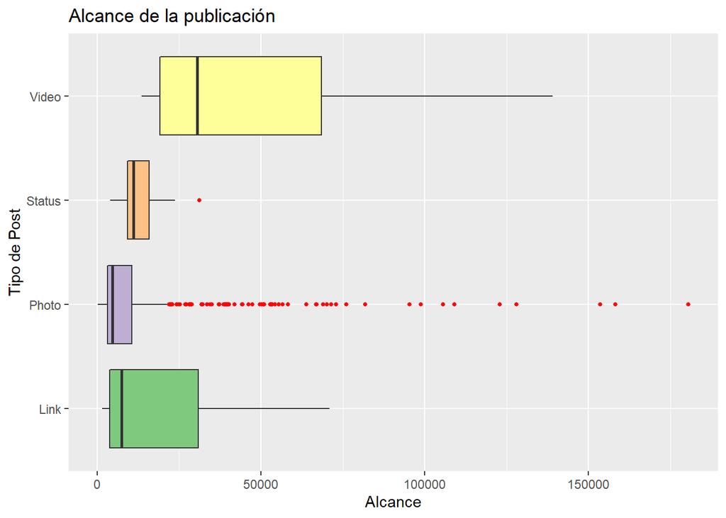

El gráfico BoxPlot sirve para ver cómo es la **dispersión de los datos**. Por ejemplo, tomemos el boxplot de los videos. La caja amarilla contiene el 50% de los datos. El **límite inferior** de esta corresponde al primer cuartil (**25% de los datos**) y el **límite superior** el tercer cuartil (**75% de los datos**). La línea del medio es la mediana (**50% de los datos**) y las líneas que salen de la caja corresponde a los datos que superan el primer o tercer cuartil.

Además, los puntos que aparecen en rojo corresponden a **outliers** (datos que están bastante alejados del resto).

Como podemos ve,r la categoría `Video` es la que **mayor mediana** tiene. No obstante hay que tener en cuenta que hay solo 7 datos sobre este post en nuestra base.

Sobre la categoría `Status` o Estado, vemos que tiene una **menor mediana** en comparación a los **videos** pero levemente **mayor** a la de los **otros tipos de post**. Además presenta un valor extremo por la parte superior.

Respecto de la categoría `link` destacamos que, a pesar de tener una **mediana menor que los estados**, su **tercer cuartil** es mayor.

Por último, en el caso de la variable `Photo` o Foto, si bien es la que **menor mediana** tiene, es la que más datos presenta. Además, podemos ver que tiene **muchos valores extremos o outliers**. Notamos que la mediana está cercana al límite inferior del cajón, lo que quiere decir que la mitad de los datos se encuentran bajo ese valor, con un alcance bastante pequeño, mientras que la otra mitad se encuentra sobre ese valor, con un alcance bastante mayor.

La siguiente tabla muestra los estadísticos de resúmen para los tipos de publicaciones.

| Tipo de Post | Mediana | Media | Desviación Estándar | Mínimo | Máximo |
| --- | --- | --- | --- | --- | --- |
| Link | 7422 | 18545 | 21399 | 1536 | 70912 |
| Foto | 4675 | 13138 | 22878 | 238 | 180480 |
| Video | 30624 | 51206 | 48825 | 13544 | 139008 |
| Estado | 11096 | 13079 | 5218 | 3930 | 31136 |

Podemos observar en la tabla anterior que **los videos tienen mayor mediana y media** que los demás tipos de post. No obstante, al ser pocos datos, también tienen una gran dispersión.

Además, el **máximo alcance de las fotos** es mayor que el de cualquier otro tipo de post. No obstante, tiene una mediana bastante pequeña, siendo la menor de las categorías. Sobre la media advertimos que es de las más bajas junto con la de los estados.

Esto nos permite afirmar que, en general, los videos suelen tener un mayor alcance que los demás post. Sin embargo, hay que tener en cuenta que hay pocos datos en esta categoría. Cabe destacar que los **Estados tienen una media y mediana bastante parecida**, por lo que su dispersión es poca, con una desviación bastante pequeña, por lo que es probable que un post se encuentre cercano a estos valores.

## Impresiones Totales

Esta variable se refiere a la **cantidad de veces que se ve tu post**. A diferencia de la variable anterior, en este caso, si un usuario ve más de una vez tu post, se contabilizan todas las veces que lo haya visto, es decir, **un único usuario puede generar más de una impresión**.

Veamos gráficamente cómo se comporta.

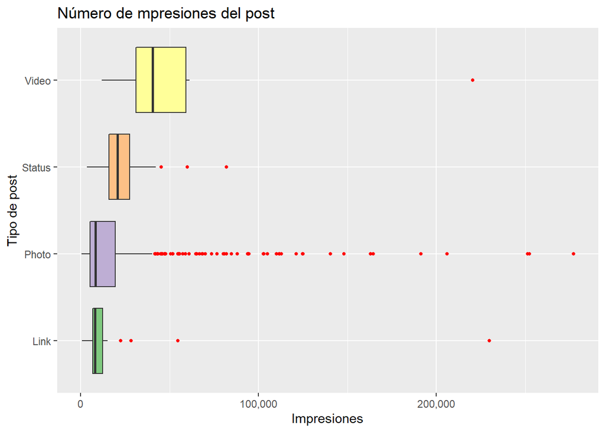

Analicemos sus estadísticos de resúmen.

[output not shown]

Como observamos los post tipo **video son los que tienen mayor mediana y media**. No obstante, tienen una gran dispersión en sus datos. Los **links** se comportan parecido a las fotos, sin embargo el máximo de este último es bastante mayor. Luego, respecto de los **estados**, vemos que tienen mayor mediana y menor media que las dos categorías anteriores.

Esto nos permite afirmar que los **videos tienen un mayor número de impresiones**. No obstante, los **estados tienen una distribución bastante simétrica**, además el mínimo de impresiones es más grande que el de los links y fotos. Sobre esta última, algo importante, es que posee varios datos que están por sobre el tercer cuartil, en otras palabras, hay hartas publicaciones que tienen un gran número de impresiones, a pesar de que la categoría tiene una pequeña mediana y media.

## Interacciones

Esta variable la vamos a separar en dos. En primer lugar, vamos a analizar el número de interacciones que genera cada tipo de post **sobre tu página**. En segundo lugar, vamos a ver cómo interactúa la gente **con tu mismo post**.

### Interacciones con tu página

Esta variable se refiere al número total de **interacciones de tu página**, es decir, likes, shares, follow, contacto, búsqueda, entre otros.

Veamos gráficamente cómo se comporta

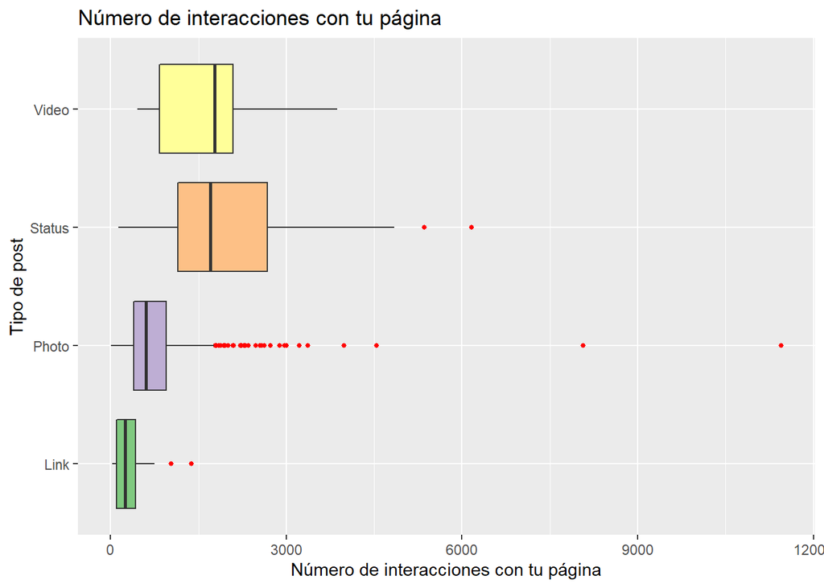

Podemos ver que los videos y estados tienen una **mediana similar** y mayor que la de las otras dos categorías. No obstante, tanto el **primer cuartil como el tercero, son mayores** que el de los videos. Por lo que esta categoría suele generar un mayor número de interacciones. Además, los post que **menor número de interacciones** genera son los **links**.

Veamos en una tabla estos datos.

| Tipo de Post | Mediana | Media | Desviación Estándar | Mínimo | Máximo |
| --- | --- | --- | --- | --- | --- |
| Link | 244 | 343 | 340 | 24 | 1374 |
| Foto | 606 | 819 | 868 | 9 | 11452 |
| Video | 1779 | 1707 | 1175 | 459 | 3872 |
| Estado | 1701 | 2040 | 1352 | 128 | 6164 |

Efectivamente, los links y las fotos tienen **medianas y medias** más chicas que las otras dos categorías. Sin embargo, el máximo número de interacciones generadas por las fotos es mayor que el de los otros 3 tipos de post. Como vemos, las medianas de los videos y estados **son parecidas**, sin embargo, **la media** de esta última es **mayor**.

Otro aspecto que destacar es que, si bien los estados y los videos generan más interacciones, también son las que **mayor dispersión** tienen a diferencia de las otras dos categorías.

Como conclusión, los **estados y los videos** son los que **mayor número de interacciones** con tu página generan, ya sea nuevos seguidores, mayor número de me gustas o de contactos.

### Interacciones con tu post

Este análisis se refiere a la cantidad de interacciones que **genera tu post**. A diferencia de las interacciones de la página, ahora vamos a analizar solo las interacciones de tu publicación, sin contar los nuevos seguidores ni las visitas al perfil.

Veamos gráficamente como se comportan las publicaciones.

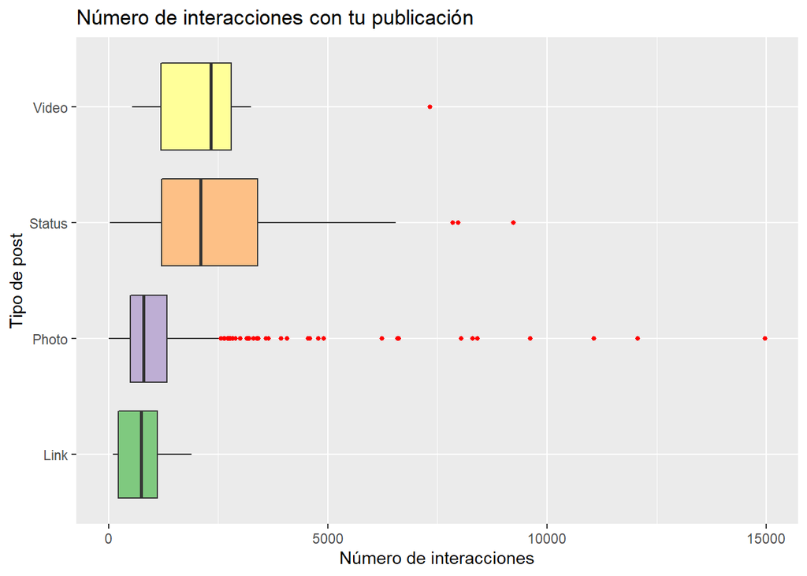

Como podemos ver en el gráfico, a pesar de que los estados tengan una mediana parecida a la de los videos, su **tercer cuartil es mayor** que el de esta categoría. Sobre los links, vemos que se comportan parecido a las fotos. Sin embargo, esta última tiene una mayor cantidad de outliers o datos extremos.

Veamos que sucede con sus medidas de resúmen.

[output not shown]

Destacamos que, al igual que las interacciones con la página, los estados y los videos tienen una **mayor media y mediana** que la de las otras categorías. Sin embargo, la media de los estados es de 2800 aproximadamente, mientras que la de los videos es de 2600. Notamos que los links nuevamente son las que **menores interacciones** generan, con mediana y media bastante pequeña.

Como conclusión, podemos decir que **los estados** son una las publicaciones que **más interacciones generan**, seguido de los videos. Notamos tambien que los links no suelen generar gran número de interacciones. Sobre las fotos, cabe mencionar que su máximo número de interacciones que genera, tanto en el post como en la página, es mayor que la de las otras 3 categorías.

## Likes, comentarios y shares.

En esta variable vamos a analizar el número de likes, comentarios y veces compartidas de tu post.

### Likes

Esta variable se refiere al número de likes que tiene tu publicación.

Veamos gráficamente como se comportan cada tipo de publicación.

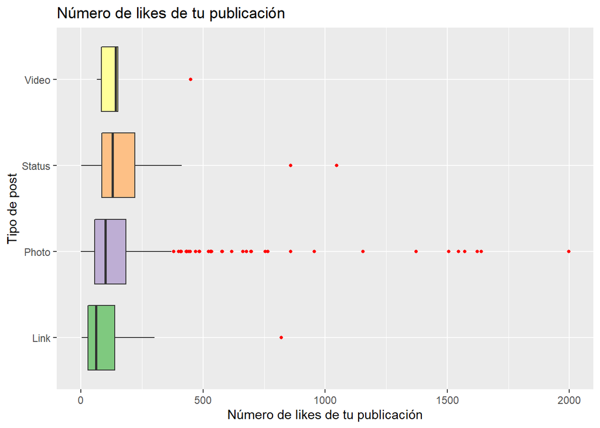

### Comentarios

Esta variable se refiere al número de comentarios que tiene tu publicación.

Veamos gráficamente como se comportan.

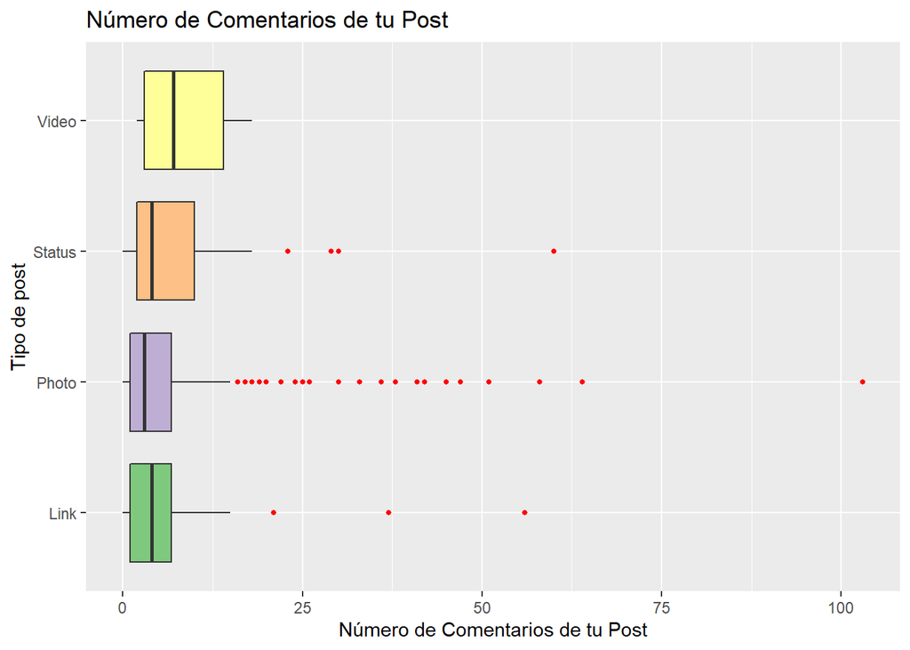

Notamos que, los videos tienen, en general, el mayor número de comentarios. Sobre las otras tres categorías notamos que son bastante parecidas. Cabe destacar que las fotos, nuevamente, tienen una gran cantidad de outliers.

### Compartidos

Esta variable se refiere al número de veces que se comparte, con otros usuarios, tu publicación.

Veamos gráficamente como se comporta.

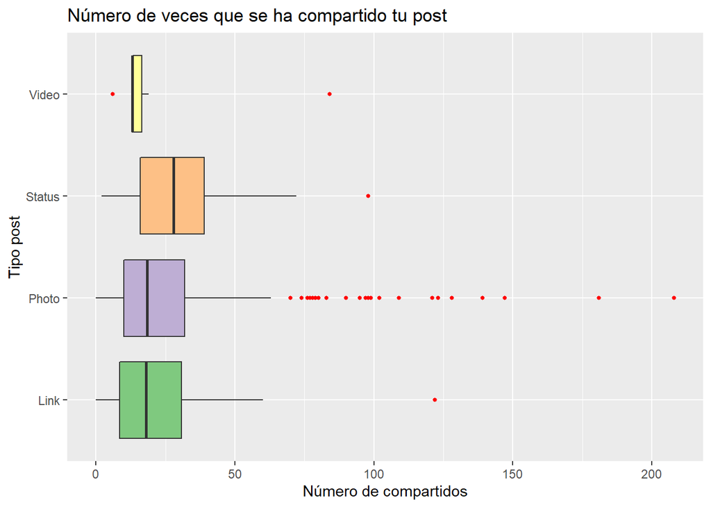

Como observamos, los estados tienen la mayor mediana, seguido de los links y las fotos. Mientras que los videos son los menos compartidos.